# Wearables

Felix Proessl

2022-10-04

## Wearables lecture

This R Markdown document serves as an adjunct to the Wearables lecture of `HRS2665 Applied Sports Science` at the University of Pittsburgh. The script will provide an introductory lesson on:

1. How to read in data
2. How to work with and manipulate dates
3. How to visualize time-series data using ggplot

### Step 1: Import packages

Think of `packages` as toolboxes, which allow you to use certain functions. People spend months developing these packages and each package is reviewed by the R community before released to the public. Although this review process does not necessarily prohibit errors, the likelihood of errors decreases, particularly in widely used packages such as those in this script.

As part of this course, we will predominantly work within the `tidyverse` - a set of packages developed by **Hadley Wickham**, Chief Scientist at **RStudio** and Adjunct Professor of Statistics at the University of Auckland, Stanford University and Rice University. You can learn more about Hadley on [Twitter](https://twitter.com/hadleywickham?ref_src=twsrc%5Egoogle%7Ctwcamp%5Eserp%7Ctwgr%5Eauthor) or [here](https://hadley.nz/). In this tutorial specifically, we will use `readr` to read in data, `dplyr` to manipulate and transform data, and `ggplot2` to visualize data.

Let’s start by importing these packages

```r
library(ggplot2)
library(dplyr)
library(readr)
```

### Step 2: Import data

We will now use the **read_csv()** function from the `readr` package to import a dataset that tracks biometric information of one individual who tested positive for COVID. Data is derived from an OURA ring (Gen. 2). The data will be stored to a new variable called `df`.

### Step 3: Data exploration

Whenever working with a dataset, it is always a good idea to first explore its structure. Essentially, we want to find out things like how many and what variables we are working with, how many data points we have access to and what kind of data we work with (e.g., dates, strings, numeric). It is also helpful to get a quick snapshot into the range of values for each variable. To do so, we will use the **str()**, **dim()**, and **summary()** functions.

#### Data structure

```r
str(df)
```

```
## spec_tbl_df [37 × 54] (S3: spec_tbl_df/tbl_df/tbl/data.frame)
##  $ date                       : chr [1:37] "8/4/22" "8/5/22" "8/6/22" "8/7/22" ...
##  $ Sleep Score                : num [1:37] 75 67 67 63 75 76 65 80 78 72 ...
##  $ Total Sleep Score          : num [1:37] 66 60 50 39 68 62 48 71 75 60 ...
##  $ REM Sleep Score            : num [1:37] 63 63 40 34 47 57 34 74 48 34 ...
##  $ Deep Sleep Score           : num [1:37] 96 80 97 95 100 99 98 100 100 100 ...
##  $ Sleep Efficiency Score     : num [1:37] 83 62 74 93 95 86 76 93 86 83 ...
##  $ Restfulness Score          : num [1:37] 64 62 74 66 68 77 69 74 71 70 ...
##  $ Sleep Latency Score        : num [1:37] 81 67 70 83 72 86 67 70 91 86 ...
##  $ Sleep Timin Score          : num [1:37] 100 100 100 86 100 100 100 100 89 100 ...
##  $ Total Sleep Duration       : num [1:37] 23430 22050 19410 16590 23970 ...
##  $ Total Bedtime              : num [1:37] 27420 29040 24060 18660 26640 ...
##  $ Awake Time                 : num [1:37] 3990 6990 4650 2070 2670 3510 4110 3030 4170 3840 ...
##  $ REM Sleep Duration         : num [1:37] 4560 4530 2910 2550 3450 4140 2490 5340 3540 2580 ...
##  $ Light Sleep Duration       : num [1:37] 12390 12780 9780 8460 11520 ...
##  $ Deep Sleep Duration        : num [1:37] 6480 4740 6720 5580 9000 8520 7290 10200 9330 9150 ...
##  $ Restless Sleep             : num [1:37] 37 37 26 32 31 32 30 19 29 33 ...
##  $ Sleep Efficiency           : num [1:37] 85 76 81 89 90 86 82 89 86 85 ...
##  $ Sleep Latency              : num [1:37] 1320 180 240 540 300 1200 180 1530 750 630 ...
##  $ Sleep Timing               : num [1:37] 13950 15270 10830 9090 13260 ...
##  $ Bedtime Start              : POSIXct[1:37], format: "2022-08-04 02:59:47" "2022-08-05 02:07:05" ...
##  $ Bedtime End                : POSIXct[1:37], format: "2022-08-04 10:36:47" "2022-08-05 10:11:05" ...
##  $ Average Resting Heart Rate : num [1:37] 57 50.9 58.8 48.3 49.1 ...
##  $ Lowest Resting Heart Rate  : num [1:37] 52 46 51 44 44 47 42 48 46 45 ...
##  $ Average HRV                : num [1:37] 51 69 52 78 71 57 66 62 58 67 ...
##  $ Temperature Deviation (°C) : num [1:37] 0.06 -0.11 0.06 -0.42 0.18 -0.35 -0.53 0.16 -0.11 0.09 ...
##  $ Temperature Trend Deviation: num [1:37] 0.16 0.06 0.03 -0.13 -0.05 -0.12 -0.27 -0.18 -0.04 0.05 ...
##  $ Respiratory Rate           : num [1:37] 13 13.4 13.2 12.6 12.5 ...
##  $ Activity Score             : num [1:37] 98 97 96 94 84 94 94 94 89 88 ...
##  $ Stay Active Score          : num [1:37] 83 87 97 97 55 67 70 75 71 70 ...
##  $ Move Every Hour Score      : num [1:37] 100 100 100 100 100 100 95 100 95 100 ...
##  $ Meet Daily Targets Score   : num [1:37] 100 100 100 100 100 95 95 95 78 95 ...
##  $ Training Frequency Score   : num [1:37] 100 100 100 100 100 100 100 100 100 100 ...
##  $ Training Volume Score      : num [1:37] 100 100 100 100 100 100 100 100 100 100 ...
##  $ Activity Burn              : num [1:37] 768 887 1407 1138 1012 ...
##  $ Total Burn                 : num [1:37] 2857 3036 3615 3245 3103 ...
##  $ Steps                      : num [1:37] 17327 21259 31435 22609 12972 ...
##  $ Equivalent Walking Distance: num [1:37] 15471 18370 27984 22365 16621 ...
##  $ Inactive Time              : num [1:37] 29520 27420 21480 20640 43140 ...
##  $ Rest Time                  : num [1:37] 28800 25680 20760 31080 24120 ...
```

[output cut: 58 more lines]

```
##   ..   `High Activity Time` = col_double(),
##   ..   `Non-wear Time` = col_double(),
##   ..   `Average MET` = col_double(),
##   ..   `Long Periods of Inactivity` = col_double(),
##   ..   `Readiness Score` = col_double(),
##   ..   `Previous Night Score` = col_double(),
##   ..   `Sleep Balance Score` = col_character(),
##   ..   `Previous Day Activity Score` = col_character(),
##   ..   `Activity Balance Score` = col_character(),
##   ..   `Temperature Score` = col_double(),
##   ..   `Resting Heart Rate Score` = col_double(),
##   ..   `HRV Balance Score` = col_character(),
##   ..   `Recovery Index Score` = col_double()
##   .. )
##  - attr(*, "problems")=<externalptr>
```

#### Dataset dimensions

```r
dim(df)
```

```
## [1] 37 54
```

#### Basic descriptive statistics

```r
summary(df)
```

```
##      date            Sleep Score    Total Sleep Score REM Sleep Score
##  Length:37          Min.   :52.00   Min.   :29.00     Min.   :21.00
##  Class :character   1st Qu.:67.00   1st Qu.:51.00     1st Qu.:34.00
##  Mode  :character   Median :74.00   Median :62.00     Median :48.00
##                     Mean   :72.57   Mean   :61.59     Mean   :53.81
##                     3rd Qu.:76.00   3rd Qu.:70.00     3rd Qu.:69.00
##                     Max.   :91.00   Max.   :88.00     Max.   :95.00
##  Deep Sleep Score Sleep Efficiency Score Restfulness Score Sleep Latency Score
##  Min.   : 80.00   Min.   :55.00          Min.   :56.00     Min.   : 1.00
##  1st Qu.: 96.00   1st Qu.:83.00          1st Qu.:65.00     1st Qu.:67.00
##  Median : 98.00   Median :88.00          Median :70.00     Median :78.00
##  Mean   : 97.08   Mean   :85.49          Mean   :69.65     Mean   :73.84
##  3rd Qu.: 99.00   3rd Qu.:93.00          3rd Qu.:73.00     3rd Qu.:83.00
##  Max.   :100.00   Max.   :96.00          Max.   :97.00     Max.   :97.00
##  Sleep Timin Score Total Sleep Duration Total Bedtime     Awake Time
##  Min.   : 10.0     Min.   :14040        Min.   :16020   Min.   :1980
##  1st Qu.:100.0     1st Qu.:19860        1st Qu.:23520   1st Qu.:2970
##  Median :100.0     Median :22500        Median :25800   Median :3450
##  Mean   : 95.3     Mean   :22425        Mean   :26097   Mean   :3671
##  3rd Qu.:100.0     3rd Qu.:24600        3rd Qu.:28680   3rd Qu.:4110
##  Max.   :100.0     Max.   :29070        Max.   :34320   Max.   :9150
##  REM Sleep Duration Light Sleep Duration Deep Sleep Duration Restless Sleep
##  Min.   :1590       Min.   : 5940        Min.   : 4740       Min.   :14.00
##  1st Qu.:2550       1st Qu.: 9420        1st Qu.: 6510       1st Qu.:26.00
##  Median :3540       Median :10230        Median : 7800       Median :30.00
##  Mean   :3932       Mean   :10821        Mean   : 7673       Mean   :29.38
##  3rd Qu.:5010       3rd Qu.:12690        3rd Qu.: 8580       3rd Qu.:33.00
##  Max.   :6990       Max.   :15930        Max.   :10500       Max.   :40.00
##  Sleep Efficiency Sleep Latency     Sleep Timing
##  Min.   :73.00    Min.   : 150.0   Min.   : 8340
##  1st Qu.:85.00    1st Qu.: 300.0   1st Qu.:12180
##  Median :87.00    Median : 480.0   Median :12810
##  Mean   :85.97    Mean   : 784.9   Mean   :13142
##  3rd Qu.:89.00    3rd Qu.: 750.0   3rd Qu.:14610
##  Max.   :91.00    Max.   :6750.0   Max.   :19140
##  Bedtime Start                     Bedtime End
##  Min.   :2022-08-04 02:59:47.00   Min.   :2022-08-04 10:36:47.00
##  1st Qu.:2022-08-15 01:56:50.00   1st Qu.:2022-08-15 09:06:50.00
##  Median :2022-09-01 02:46:34.00   Median :2022-09-01 10:44:34.00
##  Mean   :2022-08-31 10:24:46.83   Mean   :2022-08-31 17:39:43.58
```

[output cut: 57 more lines]

```
##  Max.   :87.00   Max.   :100.00
##  Previous Day Activity Score Activity Balance Score Temperature Score
##  Length:37                   Length:37              Min.   :  1.00
##  Class :character            Class :character       1st Qu.: 91.00
##  Mode  :character            Mode  :character       Median : 97.00
##                                                     Mean   : 87.57
##                                                     3rd Qu.:100.00
##                                                     Max.   :100.00
##  Resting Heart Rate Score HRV Balance Score  Recovery Index Score
##  Min.   :  1.00           Length:37          Min.   : 17.00
##  1st Qu.: 90.00           Class :character   1st Qu.: 72.00
##  Median : 96.00           Mode  :character   Median : 88.00
##  Mean   : 85.49                              Mean   : 80.41
##  3rd Qu.:100.00                              3rd Qu.:100.00
##  Max.   :100.00                              Max.   :100.00
```

### Step 4: Data visualization

Now that we know more about the dataset, let’s start working with it. The goal is to visualize Temperature Deviations over time, since OURA is arguably able to detect the onset of COVID-related symptoms, such as elevated body temperatures. In order to visualize values over time, we first need to tell R in which way our **dates** variable is formatted , since there are a number of ways to describe dates (e.g., October 4, 2022 vs. 10/4/2022 vs. 10/04/22 vs. 10-04-2022), all of which are valid. To do so, we will use the **mutate()** function from the `dplyr` package, which allows us to either create a new variable (aka column), or overwrite an existing one, depending on the whether or not we name the variable the same or differently. In this case, we will just create a new variable called **date_formatted**. To store this newly formatted variable, we also need to update our existing dataframe, `df`. To avoid having too many dataframes, we will simply overwrite our existing dataframe using the same name.

```r
df <- df %>%
  mutate(date_formatted = as.Date(date, format =  "%m/%d/%y"))
```

### Step 5: Visualize

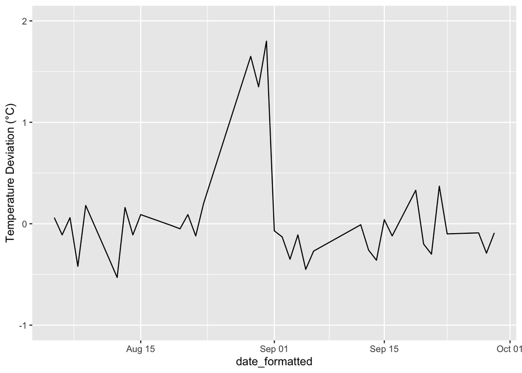

```r
df %>%
  ggplot(aes(x = date_formatted,
             y = `Temperature Deviation (°C)`)) +
  geom_line() +
  scale_y_continuous(limits = c(-1, 2))
```

### Step 5: Contextualize

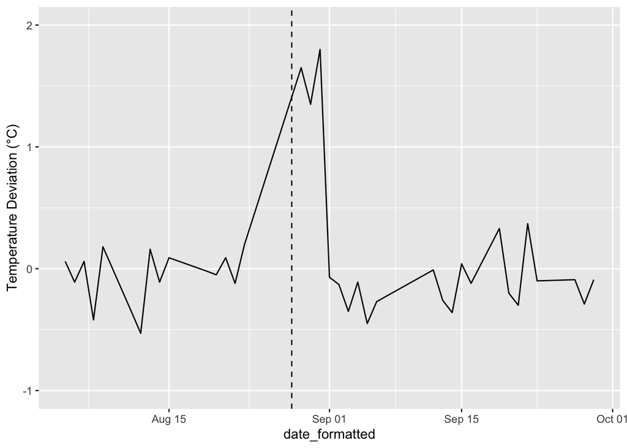

```r
df %>%
  ggplot(aes(x = date_formatted,
             y = `Temperature Deviation (°C)`)) +
  geom_line() +
  geom_vline(xintercept = as.Date("8/28/22", format = "%m/%d/%y"),
             linetype = "dashed") +
  scale_y_continuous(limits = c(-1, 2))
```